### Magnetic and Nematic Orders of the Two-Dimensional Electron Gas at Oxide (111) Surfaces and Interfaces

Nazim Boudjada, Gideon Wachtel, Arun Paramekanti

*Introduction.—* Transition metal oxide heterostructures and interfaces can realize exotic low-dimensional electronic phases and allow for engineering oxide-based devices @Review2014. Extensive research @ohtomo2004high [@thiel2006tunable; @nakagawa2006some; @Millis2006; @reyren2007superconducting; @caviglia2008electric; @caviglia2010tunable; @Ariando2011; @bert2011direct; @li2011coexistence; @macdonald_001; @mehta2012evidence; @held_001; @fischer_spinorbit_2013; @kim2013origin; @banerjee2013ferromagnetic; @chen2013; @Park2013; @ruhman_competition_2014; @caviglia_001; @Taraphder2016; @tolsma_orbital_2016; @atkinson2017influence] has focused on the two-dimensional electron gas (2DEG) at the (001) LaAlO$_3$-SrTiO$_3$ (LAO-STO) interface induced by a combination of the polar catastrophe and oxygen vacancies. This 2DEG shows evidence of correlated magnetism in torque magnetometry and scanning SQUID measurements @bert2011direct [@li2011coexistence]. In addition, it exhibits superconductivity (SC) @reyren2007superconducting [@PhysRevLett.107.056802] which may be tied to that of doped bulk STO, though the interface might harbor modulated SC pairing @Michaeli2012 or Majorana modes @Fidkowski2013.

Recently, various groups have started to probe 2DEGs at oxide (111) surfaces and interfaces, for instance induced by photon @rodel_orientational_2014 or ion @mckeown_walker_control_2014 [@miao_anisotropic_2016] irradiation at the (111) STO surface, as well as that at the (111) LAO-STO interface @rout_six-fold_2017 [@PhysRevB.95.035127; @ADMI:ADMI201600830; @monteiro_two-dimensional_2017; @davis_superconductivity_2017]. Part of this interest stems from proposals for realizing topologically nontrivial phases along this growth direction @Xiao_NComm2011 [@Ruegg_PRB2011; @Cook_PRL2014; @Okamoto_PRB2014; @Fiete_SciRep2015; @Baidya_PRB2016; @Held_2016; @Kee_NPJQM2017]. The $[111]$ growth direction is polar for STO due to alternating Ti$^{4+}$ and (SrO$_3)^{4-}$ layers, and the internal electric fields could lead to stronger confinement @baidya2015 of the (111) 2DEG, potentially enhancing correlation effects relative to (001) 2DEGs. Angle resolved photoemission spectroscopy (ARPES) on the (111) STO surface reveals a Fermi surface (FS) composed of all three $t_{2g}$ orbitals, which appears to preserve the expected hexagonal symmetry @rodel_orientational_2014 [@mckeown_walker_control_2014]. However, very recent experiments have discovered, via measurements of magnetotransport @miao_anisotropic_2016 [@rout_six-fold_2017; @PhysRevB.95.035127; @ADMI:ADMI201600830] and the resistive transition into the SC state @davis_superconductivity_2017, that this (111) 2DEG exhibits an anisotropy which sets in at low temperatures, spontaneously breaking the hexagonal symmetry. While a weak resistive anisotropy may arise from the ${\sim 100}\;\rm K$ pseudo-cubic to pseudo-tetragonal transition of bulk STO @aharony_trigonal–tetragonal_1977, the onset temperature seen in these experiments is much lower, ${T_{\rm ani}\sim 4\text{-}30\;\rm K}$ depending on the sample and the electron density. For bulk STO, it is known that the transition into the pseudo-tetragonal phase is sensitive to stress along the $[111]$ direction @muller_indication_1991, and proceeds via an intermediate trigonal phase; it remains to be tested if the lower symmetry at the (111) surface or interface leads to a low temperature surface phonon instability.

In light of these developments, it is in any case also important to consider the impact of electron-electron interactions on (111) 2DEGs, in order to (i) study possible interaction induced many-body instabilities, and (ii) ask if there are electronic mechanisms for the observed anisotropies of the (111) 2DEG which may cooperate or compete with phonon instabilities. Such an interplay has been actively investigated in the iron pnictide superconductors (see Ref. for a review).

*RPA analysis. —* To identify the leading weak-coupling instabilities we use an unbiased multi-orbital RPA approach @graser_near-degeneracy_2009, with the matrix response ${\underline{\chi}^{(c,s)}_{RPA}({\bf{q}},\Omega)=\underline{\chi}_0({\bf{q}},\Omega) (1-\underline{U}^{(c,s)}\underline{\chi}_0({\bf{q}},\Omega))^{-1}}$, where
$$\begin{aligned}
\label{eq:chi0}
& & \left(\underline{\chi}_0({\bf{q}},\Omega)\right)_{\ell_1\ell_2;\ell_3\ell_4} =
\frac{1}{N}\sum_{ij\sigma\sigma'}\int_0^\beta \mathrm{d}\tau
\,\mathrm{e}^{{\mathrm{i}}{\bf{q}}\cdot({{\bf{r}}}_i-{{\bf{r}}}_j)-{\mathrm{i}}\Omega\tau} \nonumber \\ & &
\qquad\qquad\quad\times\left\langle
c_{i\ell_1\sigma}^\dagger(\tau) c_{i\ell_2\sigma}(\tau)c_{j\ell_3\sigma'}^\dagger(0) c_{j\ell_4\sigma'}(0)
\right\rangle.\end{aligned}$$
is the bare response function (see Supplemental Material (SM)). Here, $N$ is the number of sites, $c$ and $s$ respectively denote charge and spin responses. The non-zero interaction vertex matrices are,
$$\begin{eqnarray}
& &
\label{eq:Uc}
\begin{array}{lcl}
(U^c)_{\ell\ell;\ell\ell}=-U, &\quad & (U^c)_{\ell\ell';\ell\ell'}=-2V, \\
(U^c)_{\ell\ell;\ell'\ell'}=V-\frac{3}{2}J, &\quad & (U^c)_{\ell\ell';\ell'\ell}=-2J',
\end{array} \\
& &
\label{eq:Us}
\begin{array}{lcl}
(U^s)_{\ell\ell;\ell\ell}=U, &\quad & (U^s)_{\ell\ell';\ell\ell'}=J, \\
(U^s)_{\ell\ell;\ell'\ell'}=\frac{1}{2}J-V, &\quad & (U^s)_{\ell\ell';\ell'\ell}=2J',
\end{array}
\end{eqnarray}$$
where $\ell\ne\ell'$. When the largest eigenvalue of $\underline{U}^{(c,s)}\underline{\chi}_0({\bf{q}},\Omega=0)$ is $\lambda^{(c,s)}({\bf{q}})=1$, the response function diverges, indicating an instability towards an ordered state, with corresponding eigenvectors, $f^{(c,s)}_{\ell\ell'}({\bf{q}})$. Figure [fig:rpa] shows the largest eigenvalues, $\lambda^c({\bf{q}})$ and $\lambda^s({\bf{q}})$ along high symmetry lines in the Brillouin zone (BZ) for ${\bar{n}=0.3}$, $U/t=2$ and temperature $T/t=0.02$, demonstrating the emergence of various instabilities as we vary Hund’s coupling. For our choice of experimentally motivated parameters, the leading instabilities are nearly orbital diagonal, ${f^{(c,s)}_{\ell\ell'}({\bf{q}})\approx f^{(c,s)}_{\ell}({\bf{q}})\delta_{\ell\ell'}}$.

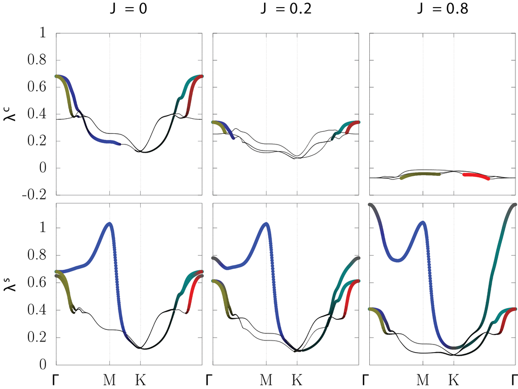

Dominant three eigenvalues $\lambda^{(c,s)}$ ($c=$ charge, $s=$ spin) of the matrix product $\underline{U}^{(c,s)}\underline{\chi}_0({\bf{q}},\Omega=0)$, plotted along high symmetry lines of the BZ, with $t = 1$, $U = 2$, $t_\perp=-t'=0.04$, and $T=0.02$, for fixed density $\bar{n}=0.3$, and varying Hund’s coupling $J/t$. Line color (red,green,blue) indicates relative weight of orbitals (respectively $xy,xz,yz$) in the orbital-diagonal part of the eigenvectors $|f^{(c,s)}_{\ell\ell}|^2$; thickness indicates total weight, $\sum_\ell|f^{(c,s)}_{\ell\ell}|^2$. The dominant instability is in the spin channel, being antiferromagnetic (near M) for small $J$ and ferromagnetic (at $\Gamma$) for large $J$. In the charge channel, the leading instability at small $J$ is a two-fold degenerate mode at $\Gamma$ corresponding to ferro-orbital order.

*Mean field theory. —* We study the phase diagram of our model, Eqns. ([eq:H0])-([eq:Hint]), using a momentum space MFT within a single-${{\bf{Q}}}$ spiral ansatz with a spatially uniform but orbital-dependent density. This is captured by a mean field Hamiltonian, ${H_{\rm var}= H_0 - \sum_{i\ell} (\phi_{\ell}+\mu) n_{i\ell}- \sum_{i\ell}{\bf b}_{\ell} \cdot {\bf S}_{i \ell} {\rm e}^{{\mathrm{i}}{{\bf{Q}}}\cdot {{\bf{r}}}_i}}$, which we use to generate variational ground states $|\psi_{\rm var}\rangle$ at the desired charge density by tuning $\mu$. The fields $\phi_{\ell},{\bf{b}}_{\ell}$, and the wavevector ${{\bf{Q}}}$ are selected to minimize $\langle\psi_{\rm var}| H_0+H_{\rm int} |\psi_{\rm var}\rangle$ (see SM).

*Effective field theory. —* Landau theory is a powerful tool to analyze magnetic orders @banerjee2013ferromagnetic and study spin textures such as skyrmions which might arise at the (001) LAO-STO interface @XLi2014. For the (111) 2DEG, our RPA analysis suggests that the soft electronic modes include a complex nematic charge mode ${\psi_n = \delta\rho_{xy}+\omega \delta\rho_{yz}+\omega^2 \delta\rho_{zx}}$ (with $\omega={\rm e}^{{\mathrm{i}} 2\pi/3}$) constructed from the slowly varying orbital densities $\delta\rho_\ell$ at the $\Gamma$-point, and the spin modes, $\vec \varphi_0$ at the $\Gamma$-point, and $\vec \varphi_\alpha$ at the magnetic wavevectors ${{\bf{Q}}}_\alpha$ ($\alpha=1,2,3$), which can describe both FM and AF orders. Since the interorbital hopping is small, $\vec \varphi_{1,2,3} \sim \vec \varphi_{xy,yz,zx}$ but with weak orbital admixture. The spin modes $\vec \varphi_\alpha$ are complex for incommensurate ${{\bf{Q}}}_\alpha$, and real if ${{\bf{Q}}}_\alpha$ correspond to the commensurate $M$-points. The nematic order parameter $\psi_n$ transforms under anticlockwise lattice ${\pi/3\text{-rotations}}$ as $\psi_n \to \omega^2 \psi_n$, and under reflections about the ${\hat{x}\text{-axis}}$ as $\psi^{\phantom\dagger}_n \to \psi^*_n$. Turning to the spin modes, $\vec \varphi_0$ is invariant under lattice symmetries, anticlockwise $\pi/3$-rotations leads to ${\vec \varphi_{1} \to \vec\varphi_{2}, \vec \varphi_{2} \to \vec\varphi_{3}, \vec \varphi_{3} \to \vec\varphi^*_{1}}$. Under spin rotations, $\psi_n$ is invariant but all spin modes undergo $SO(3)$ rotations, $\vec\varphi_{0,\alpha} \to \mathfrak{R} \vec\varphi_{0,\alpha}$. Time-reversal sends $\vec\varphi_{0,\alpha} \to - \vec\varphi_{0,\alpha}$. Armed with this, the mean field Landau free energy is ${\cal F} = \int \mathrm{d}^2 x\;( {\cal L}_\psi + {\cal L}_\varphi + {\cal L}_{\psi\varphi})$, with
$$\begin{aligned}
\!\!{\cal L}_\psi \!&=&\! r_\psi |\psi_n|^2 + w_\psi ({\psi^3_n} + {\psi^{*3}_n}) + u_\psi |\psi_n|^4 + \ldots\\
\!\!{\cal L}_\varphi \!&=&\! r_0 \vec\varphi_0 \! \cdot \!
\vec\varphi_0 \!+\! r_Q \sum_\alpha |\vec\varphi_\alpha|^2 \!+\!
\ldots \\ \!\!{\cal L}_{\psi\varphi} \!&=&\! - \lambda_1 (\psi_n^* {\cal S}^{\phantom\dagger}_n +
\psi_n^{\phantom\dagger} {\cal S}_n^* ) - \lambda_2 |\vec \varphi_0|^2 |\psi_n|^2,\end{aligned}$$
where we have defined a complex magnetic nematic order ${\cal S}_n=|\vec\varphi_1|^2 + \omega |\vec\varphi_2|^2 + \omega^2 |\vec\varphi_3|^2$ which transforms analogous to $\psi_n$. In this effective field theory, the PM phase corresponds to $(r_{\psi},r_0, r_Q >0)$, the FM phase corresponds to $(r_0<0, r_\psi, r_Q >0)$, and the various AF phases correspond to $(r_Q<0,r_0>0)$. Note that we never find a ground state nematic charge order unaccompanied by spin order in the MFT. The various types of AF orders will be dictated by higher order (quartic and sixth order) terms denoted above by ellipsis. In turn, this can lead to a ‘pinning field’ for the charge nematic order via the cubic interaction $\lambda_1$ in ${\cal L}_{\psi\varphi}$; our mean field results indicate $w_\psi, \lambda_1, \lambda_2 > 0$. Below, we discuss some implications of this Landau theory, deferring its microscopic derivation to a future publication.

**(a) Incommensurate spiral (ICS):** For the generic incommensurate instability, the simplest spin order (which will not lead to any charge modulation) is a single-mode coplanar spiral at one ${{\bf{Q}}}_\alpha$, with the complex ${\vec\varphi_\alpha = \hat{\Omega}_1 + {\mathrm{i}} \hat{\Omega}_2}$ and $\hat{\Omega}_1 \cdot \hat{\Omega}_2 =0$. This leads to ${{\cal S}_n \sim \omega^{\alpha-1}}$, so the cubic interaction $\lambda_1>0$ will pin $\psi_n \sim \omega^{\alpha-1}$, causing density enhancement in orbital $\alpha$.

**(b) Commensurate AF:** For commensurate stripe AF, ${{\bf{Q}}}_\alpha \equiv M_\alpha$, in which case $\vec\varphi_\alpha$ are real fields. This case, for which we have also carried out a real space MFT, leads to three orders. (i) AF-1 has condensation at a single $M_\alpha$, which corresponds to a collinear stripe order with $\vec\varphi_\alpha \sim \hat{\Omega}_1$. This has ${\cal S}_n \sim \omega^{\alpha-1}$, which pins ${\psi_n \sim \omega^{\alpha-1}}$, leading to a charge nematic order similar to the ICS state. (ii) AF-2 features condensation at a pair of wavevectors $M_\alpha,M_{\beta}$, with $\langle\vec\varphi_\alpha\rangle\sim \hat{\Omega}_1$ and $\langle\vec\varphi_{\beta}\rangle\sim \hat{\Omega}_2$. This state can be either collinear, $\hat\Omega_1=\hat\Omega_2$, or coplanar, $\hat{\Omega}_1 \cdot\hat{\Omega}_2 =0$. In both case, however, ${{\cal S}_n, \psi_n \sim \omega^{\alpha-1} + \omega^{\beta-1}}$, displaying charge nematic order. (iii) Finally, AF-3 is a triple-${{\bf{Q}}}$ spin crystal, similarly featuring either collinear or non-coplanar tetrahedral order of the spins. Both cases are obtained by condensation at all three $M$-points, with $\langle\vec\varphi_{1,2,3} \rangle\sim \hat{\Omega}_{1,2,3}$, and ${\cal S}_n=0$, so no charge nematic is induced. In the collinear case $\hat\Omega_1=\hat\Omega_2=\hat \Omega_3$, while in the non-coplanar spin order $\hat{\Omega}_1 \cdot \hat{\Omega}_2 =0$, and $\hat\Omega_3 =\pm \hat{\Omega}_1 \times \hat{\Omega}_2$. The latter case, in the presence of interorbital hopping, will feature an anomalous Hall effect @Martin2008 [@Kato2010]. The collinear AF-2 and AF-3 will also break translational symmetries with associated charge modulation driven by terms proportional to $\vec \varphi_\alpha \cdot \vec \varphi_{\beta} \neq 0$; such orders may be favored by repulsive interactions between neighboring sites.

**(c) Nematic FM (${\cal N}$FM):** Starting with a uniform FM state, the quartic coupling $\lambda_2>0$, if sufficiently large, can drive charge nematicity, since it can change the ‘mass’ of the nematic field to $(r_\psi - \lambda_2 |\vec \varphi_0|^2)$. This coupling between FM and nematic orders is not linear in $\psi_n$, unlike the above AFM/ICS cases. Thus, the nematicity in this case is not symmetry-enforced. For $w_\psi > 0$, the ${\cal N}$FM will have depletion of the density in one orbital, as we find from the MFT.

*Fluctuation/disorder effects. —* In 2D, without SOC, thermal fluctuations will destroy long-range magnetic order at any $T >0$. In this case, ICS, the ${\cal N}$FM, the collinear ${\text{AF-}1}$, and orthogonal AF-2, will melt into a charge nematic, reflected in a nonzero $\psi_n, {\cal S}_n$, which will undergo symmetry restoration via a $Z_3$ clock (or $3$-state Potts) transition. Within MFT this is a first order transition, but thermal fluctuations render it a continuous transition @wu_potts_1982. The non-coplanar AF-3 state will lead to a magnetically melted state with only chiral order (linked to the $\pm$ choice of $\hat{\Omega}_3$), featuring a nonzero anomalous Hall effect that vanishes above an Ising transition at which time-reversal symmetry is restored @Kato2010.

We speculate that disorder might also weakly suppress long-range magnetic order, even with SOC, leaving vestigial nematic order @Nie2014 down to $T=0$. This suggestion is motivated by Sr$_3$Ru$_2$O$_7$, where the observation of nematic transport @Borzi2014 near the metamagnetic critical point was recently attributed, via neutron scattering, to arise from *nearly* ordered SDW phases @Hayden2015.

*Discussion. —* The electronic nematic phases we have proposed in (111) 2DEGs will lead to transport anisotropies. On symmetry grounds, the scaled resistive anisotropy $(\rho_{xx}\! -\! \rho_{yy})/(\rho_{xx}\!+\! \rho_{yy})$ will track the nematic order parameter @Fradkin2000 [@Carlson2017]. A simple Drude picture (see SM) shows that, for the coordinates used above, $\rho_{xx}\!-\! \rho_{yy}\!\sim\! {\rm Re}\,\psi$ while $\rho_{xy}\!=\! \rho_{yx}\!\sim\! {\rm Im}\,\psi$. Further signatures of nematic order may be observed in Friedel oscillations which can be probed using scanning tunneling spectroscopy. Even in a conventional phonon-induced SC state, the presence of such background nematic order would lead to an anisotropy of the vortex shape and the mobility as well as the critical current, explaining the anisotropy observed in the resistive transition into the SC state @davis_superconductivity_2017. If such orbital order is weak, it will be less evident in ARPES @rodel_orientational_2014 [@mckeown_walker_control_2014] than in transport probes.

Rashba SOC @held_001 [@Park_PRB2013; @Park_PRB2012; @Park_PRL2011] does not significantly impact the (111) FS for relevant densities $\bar{n} \sim 0.3$, or lead to a significant spin-splitting near the tips of the elliptical FSs where we find the magnetic instability (see SM) since orbital mixing is negligible at those momenta. Thus, we expect SOC will not significantly modify the phase diagram at these densities; however, it can pin the magnetic order or convert the uniform FM into a long wavelength spiral @banerjee2013ferromagnetic [@XLi2014]. SOC will have a more significant impact on low density 2DEGs, and transport properties which average over the entire FS of all bands. Our work has not taken into account random oxygen vacancies - these can locally pin the nematic order but cannot induce anisotropies in macroscopically averaged resistivity measurements. However, such ‘nematogen’ defects could amplify weak resistive anisotropies, both of the bulk tetragonal phase in dilute 2DEGs, as well as of the higher density nematic phases with orbital order. This interplay, which has been studied in the pnictides @Gastiasoro_PRL2014, would be worth exploring in the oxide 2DEGs.

Finally, tetragonal lattice distortions, described by a 3-state Potts theory @aharony_trigonal–tetragonal_1977 similar to ${\cal L}_\psi$, will couple linearly to the nematic order parameter $\psi_n$ itself, affecting the SDW degrees of freedom as well. For instance, a tetragonal distortion with elongation of the ${c\text{-axis}}$ will favor the nematic order associated with the AF-1 state. The interplay of electronic nematicity explored here, with anisotropies induced by surface phonon mechanisms, is an important topic for future research.

#### Acknowledgement

We thank F. Y. Bruno, Q. Li, L. Miao, A. Chubukov, and E. Fradkin for useful discussions and feedback. This research was supported by NSERC of Canada. AP acknowledges the support and hospitality of the International Center for Theoretical Sciences (Bangalore) during completion of this manuscript.

# Supplemental Material

## Details of RPA calculation

The bare susceptibility, which is the building block of the RPA approximations, can be written in terms of the single particle Green’s functions as
$$\label{eq:chi0G}
\left(\chi_0({\bf{q}},\Omega)\right)_{\ell_1\ell_2;\ell_3\ell_4}
= \frac{1}{N\beta}\sum_{{{\bf{k}}},\omega_n}
G_{\ell_2\ell_3}({{\bf{k}}},\omega_n)G_{\ell_4\ell_1}({{\bf{k}}}+{\bf{q}},\omega_n+\Omega)$$
Given the unitary matrix $\underline{u}({{\bf{k}}})$ which diagonalizes $\underline{h}({{\bf{k}}})$, and its eigenvalues $\varepsilon_m({{\bf{k}}})$, the Green function is
$$\label{eq:G0}
G_{\ell\ell'}({{\bf{k}}},\omega_n)=\sum_{m=1}^3\frac{u_{\ell m}({{\bf{k}}})u_{\ell' m}^*({{\bf{k}}})}
{{\mathrm{i}}\omega_n-\varepsilon_m({{\bf{k}}})+\mu}.$$
Using this we compute the RPA response ${\underline{\chi}^{(c,s)}_{RPA}({\bf{q}},\Omega)=\underline{\chi}_0({\bf{q}},\Omega) (1-\underline{U}^{(c,s)}\underline{\chi}_0({\bf{q}},\Omega))^{-1}}$. In order to understand the instabilities, it suffices to focus on the matrix product $\underline{U}^{(c,s)}\underline{\chi}_0({\bf{q}},\Omega=0)$; if its eigenvalues exceed unity, it signals an RPA instability. The RPA results for different electron densities are presented in figure [fig:rpa2]. In the small $J$ regime and for small densities, the leading instability is a $2k_F$ instability in the spin channel in the $\Gamma\to$ M direction, which is commensurate for specific densities and incommensurate in general. The $\bar{n}=0.3$ electrons per site is an example of a commensurate order, which we study in the main text using a $2\times2$ unit cell. For larger densities, when $2k_F$ exceeds the length of the reciprocal lattice vectors, the ordering wavevector moves to the M $\to$ K direction. When Hund’s coupling is large, we get a FM transition corresponding to a leading instability at the $\Gamma$ point.

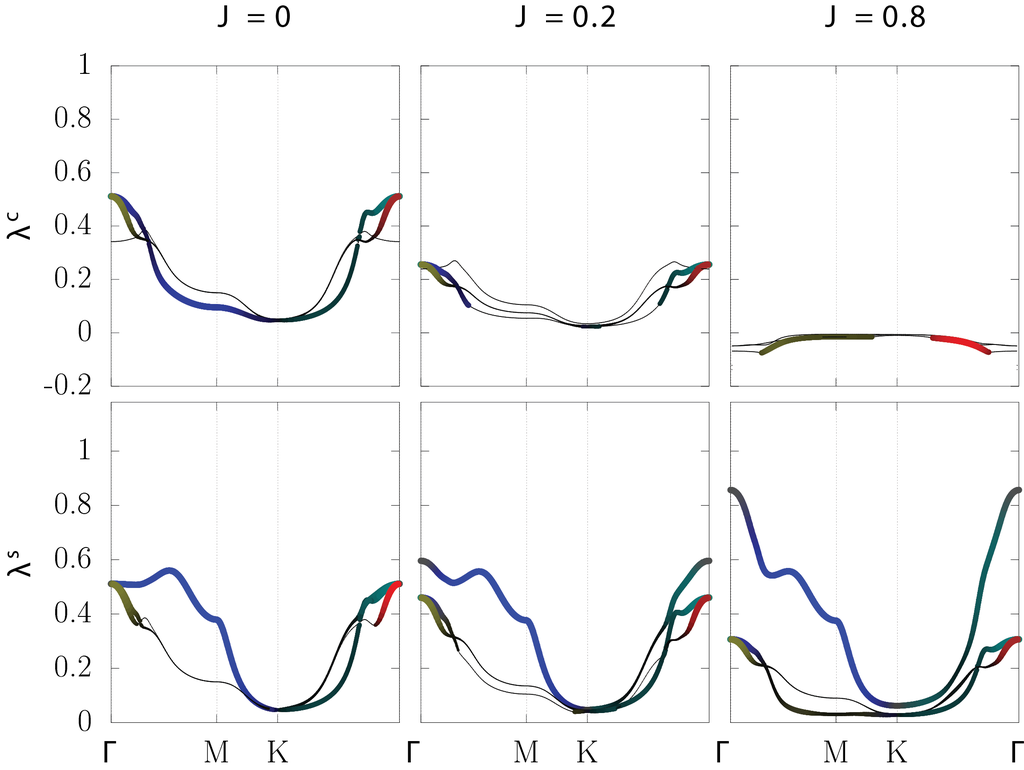

Dominant three eigenvalues $\lambda^{(c,s)}$ ($c$=charge, $s$=spin) of the matrix product $\underline{U}^{(c,s)}\underline{\chi}_0({\bf{q}},\Omega=0)$ for densities (a) $\bar{n}=0.15$, (b) $\bar{n}=0.30$, and (c) $\bar{n}=0.45$ and indicated Hund’s coupling. The color indicates the orbital content: red=$xy$, green=$xz$, blue=$yz$.

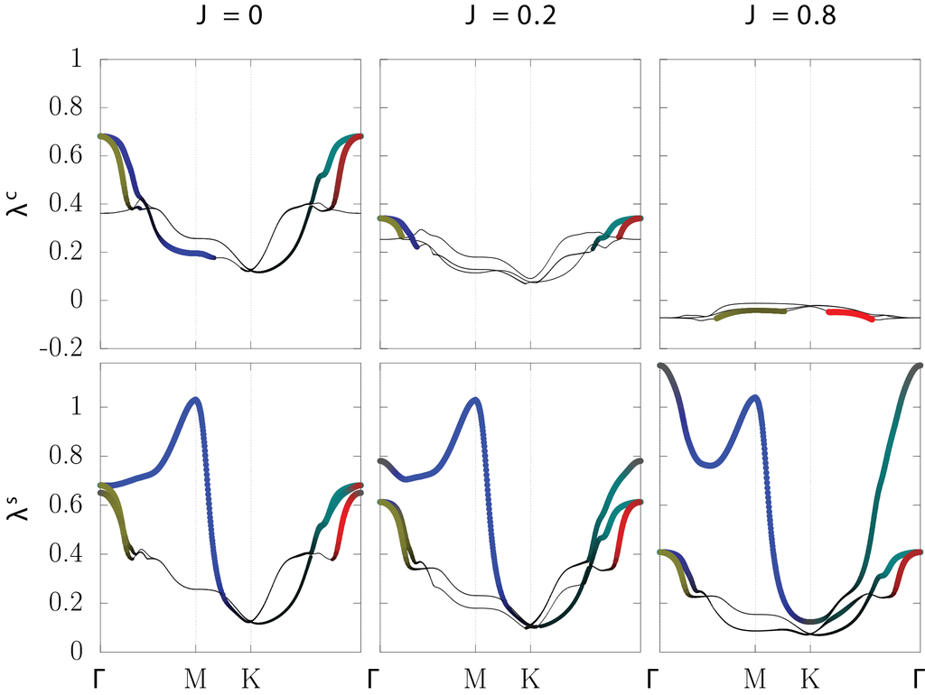

Dominant three eigenvalues $\lambda^{(c,s)}$ ($c$=charge, $s$=spin) of the matrix product $\underline{U}^{(c,s)}\underline{\chi}_0({\bf{q}},\Omega=0)$ for densities (a) $\bar{n}=0.15$, (b) $\bar{n}=0.30$, and (c) $\bar{n}=0.45$ and indicated Hund’s coupling. The color indicates the orbital content: red=$xy$, green=$xz$, blue=$yz$.

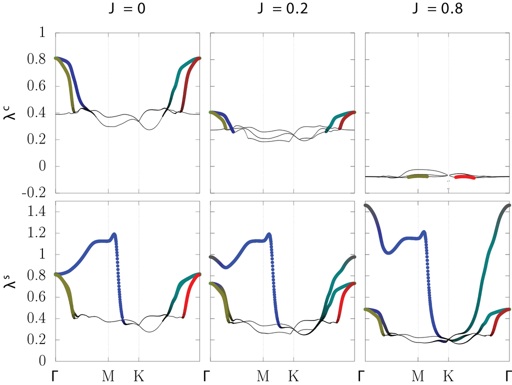

Dominant three eigenvalues $\lambda^{(c,s)}$ ($c$=charge, $s$=spin) of the matrix product $\underline{U}^{(c,s)}\underline{\chi}_0({\bf{q}},\Omega=0)$ for densities (a) $\bar{n}=0.15$, (b) $\bar{n}=0.30$, and (c) $\bar{n}=0.45$ and indicated Hund’s coupling. The color indicates the orbital content: red=$xy$, green=$xz$, blue=$yz$.

## Spin-orbit coupling

Surface and interface 2DEGs are subject to Rashba spin-orbit coupling (SOC). This arises from a combination of inversion symmetry breaking at the interface, combined with atomic SOC.@Park_PRL2011 [@Park_PRB2012; @Park_PRB2013] The inversion breaking term is odd under ${{\bf{k}}}\rightarrow-{{\bf{k}}}$, and can be phenomenologically incorporated by allowing for inter-orbital hoppings which are ordinarily forbidden by the presence of inversion symmetry. Such terms have been labelled ‘orbital Rashba’ terms.@Park_PRL2011 [@Park_PRB2012; @Park_PRB2013] For example, an electron in the $xy$ orbital could not move to a $yz$ orbital along the $\hat{a}$ direction if inversion symmetry is not broken. However, the broken symmetry at the interface will distort the orbital cloud, leading to an inter-orbital overlap which will be either stronger or weaker depending on the hopping direction (e.g., an $xy\rightarrow yz$ hopping is strong in the $-\hat{a}$ direction but weak in the $+\hat{a}$ direction), giving rise to inter-orbital hopping terms $\propto \sin({{\bf{k}}}\cdot\textbf{r})$. When combined with atomic SOC, this leads to the Rashba effect which has been shown to play a role in (001) oxide 2DEGs. Here, we generalize this idea to the (111) 2DEG.

Explicitly, for the (111) 2DEG in momentum space, we get for the inversion breaking ‘orbital Rashba’ term $H_{OR} = \sum_{{{\bf{k}}},\ell\ell',\sigma}c^\dagger_{\ell\sigma}({{\bf{k}}})h^R_{\ell\ell'}({{\bf{k}}})c_{\ell'\sigma}({{\bf{k}}})$, where
$$h^{R}({{\bf{k}}}) = 2 {\mathrm{i}} \lambda_{OR} \begin{pmatrix}
0 & \sin(k_b)-\sin(k_c) & \sin(k_a)+\sin(k_c) \\
\sin(k_c)-\sin(k_b) & 0 & \sin(k_b)-\sin(k_a) \\
-\sin(k_a)-\sin(k_c) & \sin(k_a)-\sin(k_b) & 0 \\
\end{pmatrix}$$
and $\ell \equiv (yz,zx,xy)$. Atomic spin-orbit coupling takes the form $H_{A}= - \lambda_A\;\vec{L}\cdot\vec{S}$ with $\lambda_A\approx20$ meV (see e.g., Ref.). In the $(c_{yz,\uparrow},c_{zx,\uparrow},...,c_{xy,\downarrow})^T$ basis, we can write this as $H_{A} = {\mathrm{i}} \frac{\lambda_A}{2} \sum_{{{\bf{k}}}} \varepsilon^{\phantom\dagger}_{\ell m n} \tau^n_{\sigma\sigma'} c^\dagger_{\ell \sigma}({{\bf{k}}}) c^{\phantom\dagger}_{m \sigma'}({{\bf{k}}})$, where $\varepsilon_{\ell m n}$ is the Levi-Civita symbol and $\tau^n$ the Pauli matrices.

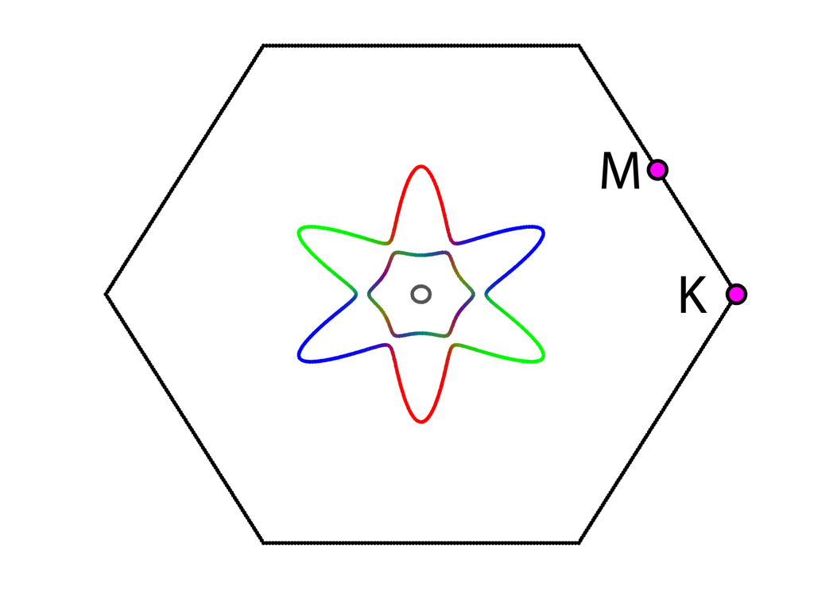

Fermi surfaces for different strengths of orbital Rashba $\lambda_{OR}$ coupling and atomic SOC $\lambda_A$ at $\bar{n}=0.3$.

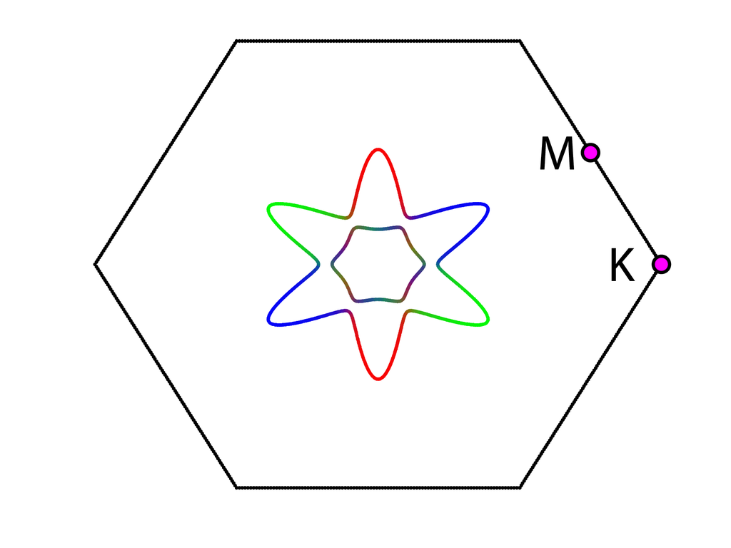

Fermi surfaces for different strengths of orbital Rashba $\lambda_{OR}$ coupling and atomic SOC $\lambda_A$ at $\bar{n}=0.3$.

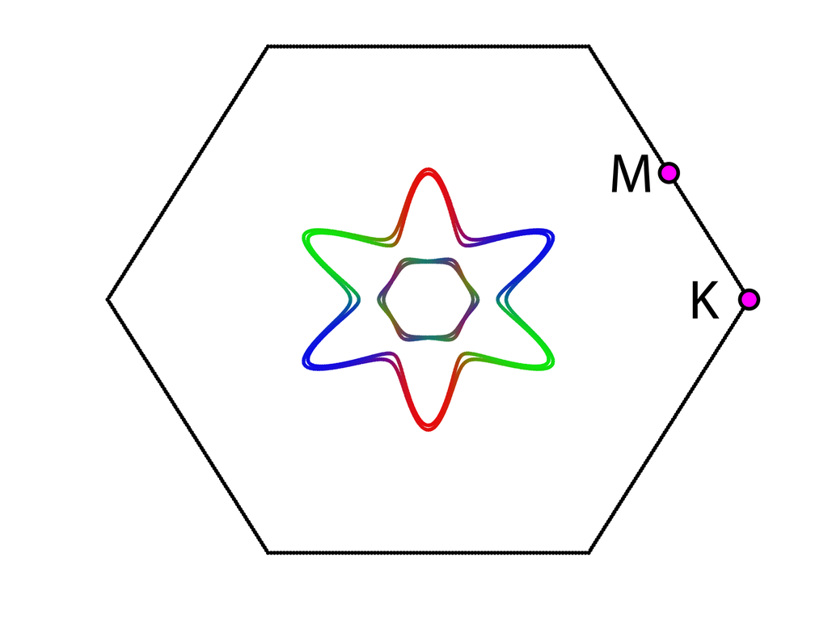

Fermi surfaces for different strengths of orbital Rashba $\lambda_{OR}$ coupling and atomic SOC $\lambda_A$ at $\bar{n}=0.3$.

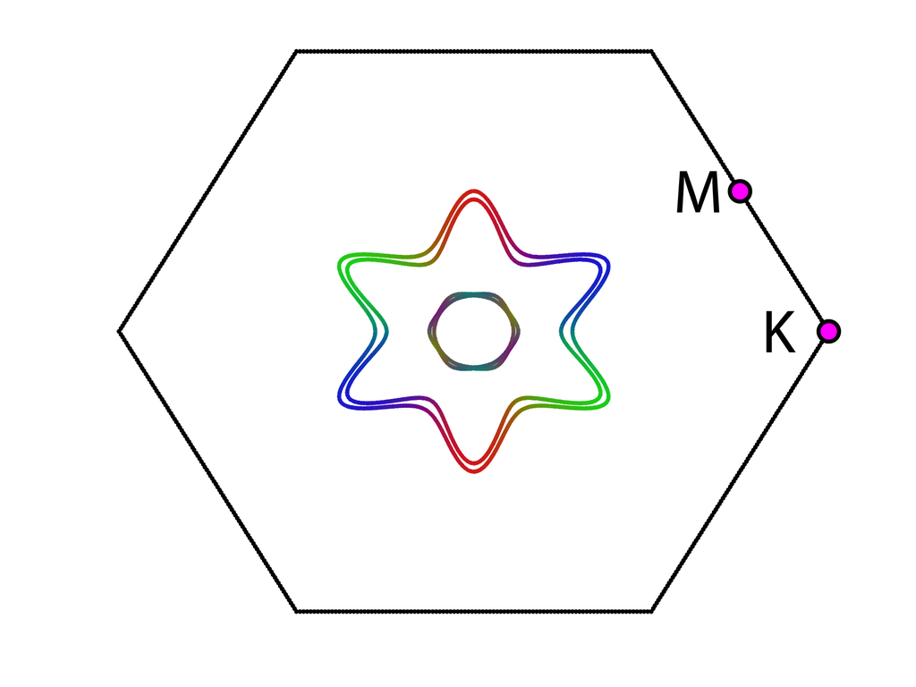

Fermi surfaces for different strengths of orbital Rashba $\lambda_{OR}$ coupling and atomic SOC $\lambda_A$ at $\bar{n}=0.3$.

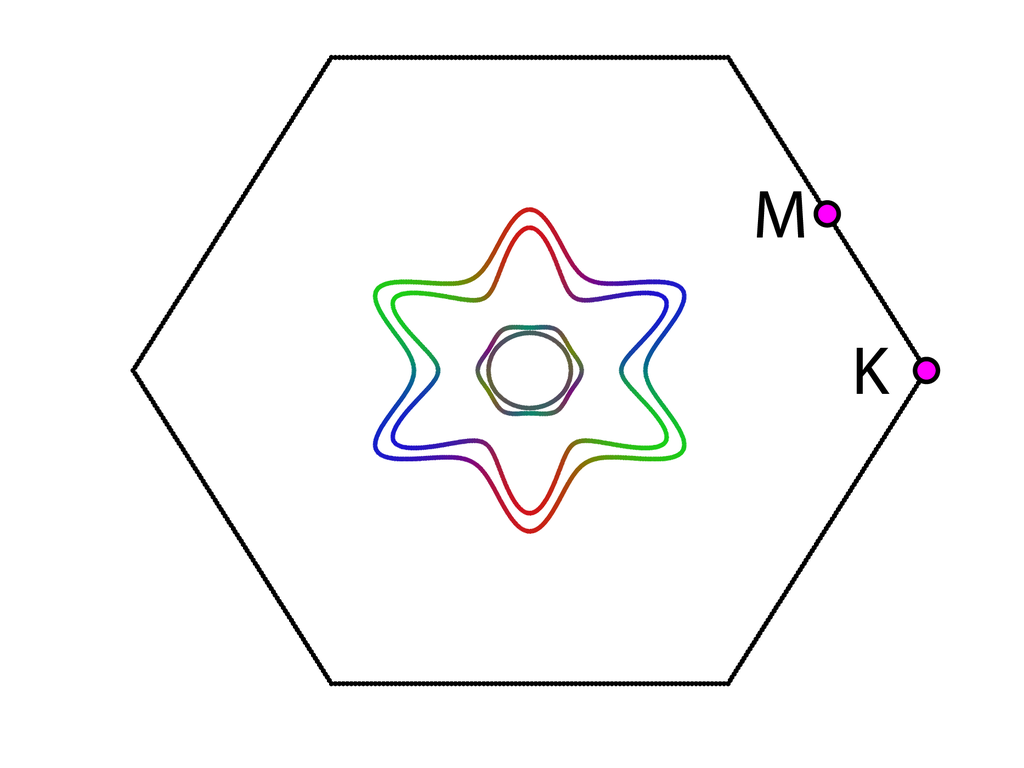

Fermi surfaces for different strengths of orbital Rashba $\lambda_{OR}$ coupling and atomic SOC $\lambda_A$ at $\bar{n}=0.3$.

What is the impact of such atomic SOC and inversion breaking on the Fermi surface? Comparing figure [fig:0] ($\lambda_A=0, \lambda_{OR}=0$) to figure [fig:A] ($\lambda_A=20$ meV, $\lambda_{OR}=0$) we see that the main effect of atomic spin-orbit coupling on the Fermi surface is the disappearance of the small band near the $\Gamma$ point, which gets pushed below the Fermi level. The leading magnetic instability uncovered in our RPA (reported in the main text and above) occurs at the wavevector connecting the tips of the elliptical Fermi surfaces. Near these tips, we find that the Fermi surface is nearly unaffected which we can understand since the Fermi surface near these regions is almost entirely composed of a single orbital. Using $\lambda_A=\lambda_{OR} = 20$ meV (see Ref.), we obtain the Fermi surface shown in figure [fig:AR]. We can see that the Rashba spin-orbit coupling breaks the spin degeneracy, previously protected by inversion and time-reversal symmetry. The tips of ellipses are once again nearly unaffected by this term, the main changes to Fermi surfaces being in the $\Gamma\rightarrow\text{K}$ direction where the different orbitals tend to strongly hybridize. However, even here the changes are small. We include figures [fig:0612] and [fig:012012] to show the effect of even larger inversion breaking on the Fermi surfaces; however we point out that these Fermi surfaces are not consistent with ARPES data on the STO surface 2DEG, suggesting that they are too large to be of relevance.

## Details of the MFT calculation

The mean field theory can be cast in the form of a variational minimization where we pick the variational state to be the ground state of a variational Hamiltonian ${H_{\rm var}= H_0 - \sum_{i\ell} (\phi_{i \ell}+\mu) n_{i\ell}- \sum_{i\ell}{\bf b}_{i \ell} \cdot {\bf S}_{i \ell}}$, with $\{\phi_{i \ell}, {\bf b}_{i \ell}\}$ being variational parameters which allow in general for site and orbital dependent order parameters. The expression for the variational free energy is given by:
$$\begin{split}
{\cal F}_{\rm var} =& \sum_{i\ell\ell'}\left\{\langle n_{i,\ell}\rangle\langle n_{i,\ell'}\rangle\left[\frac{U}{4}\delta_{\ell\ell'}+\frac{1}{2}\left(U-\frac{5}{2}J\right)(1-\delta_{\ell\ell'})\right]-\langle\mathbf{S}_{i,\ell}\rangle\cdot\langle\mathbf{S}_{i,\ell'}\rangle\left[U\delta_{\ell\ell'}+J(1-\delta_{\ell\ell'})\right]\right\}\\
&+\int_{FBZ}(\mathrm{d}^2\mathbf{k})\mathrm{Tr}(\underline{u}^\dagger(\mathbf{k}) \underline{h}(\mathbf{k})\underline{u}(\mathbf{k})\underline{n_F}(\mathbf{k}))
- T S
\end{split}
\label{eqn:FE}$$
where $\underline{u}(\mathbf{k})$ is the matrix which diagonalizes $H_{\rm var}$, $\underline{n_F}$ is the Fermi-Dirac distribution, and the thermal expectation values $\langle . \rangle$ are taken with respect to the equilibrium density matrix of the variational Hamiltonian, i.e., ${\rm e}^{-H_{\rm var}/T}$, and $S$ is the fermion entropy for given field configuration $\phi_{i\ell}$ and ${\bf b}_{i\ell}$.

We discuss two cases in the main text, a single-${{\bf{Q}}}$ spiral mean field theory which can be formulated directly in momentum space with a single site unit cell, and a case where we study broken symmetry states with $2\times 2$ real space unit cell which allows us to also explore multi-${{\bf{Q}}}$ order parameters for the commensurate AF.

### MFT with $2\times 2$ real space unit cell

We have studied the temperature dependence of a few points in the AF phases and found that as the temperature is raised, the AF-2 and AF-3 become an AF-1 phase, consistent with @nandkishore_itinerant_2012. The mean field critical temperature into the PM starting significantly deep in the AF and FM phases is $\simeq0.18t$; without SOC, this will be suppressed to zero, leaving only vestigial orbital and nematic orders. A numerical study of the renormalized $T_c$ for such vestigial orders taking full thermal fluctuations into account will be discussed elsewhere.

## Nematicity in the Drude conductivity

Simple Drude-like considerations are enough to determine how the electric conductivity depends on the nematic order parameter $\psi_n$. We begin by assuming that only $\psi_n$ has condensed and that there is no magnetic order. For simplicity, we further assume that the inter-orbital hopping is zero. Thus, each orbital, denoted by its preferred hopping direction, $\ell=a (xy), b (xz) ,c (yz)$, has a separate contribution to the conductivity tensor, $\hat\sigma=\sum_\ell\hat\sigma_\ell$. In terms of Cartesian coordinates, $x,y$, used in the main text, with $\hat{a}=\hat{x}$, $\hat{b}=\hat{x}/2+\hat{y} \sqrt{3}/2$, and $\hat{c}=-\hat{x}/2+\hat{y} \sqrt{3}/2$, we get
$$\label{eq:sigmaabc}
\hat\sigma_a=\left(
\begin{array}{cc}
\sigma_1 & 0 \\ 0 & \sigma_2
\end{array}\right),\quad
\hat\sigma_b = \left(
\begin{array}{cc}
\frac{1}{4}\sigma_1+\frac{3}{4}\sigma_2 &
\frac{\sqrt{3}}{4}(\sigma_1-\sigma_2) \\
\frac{\sqrt{3}}{4}(\sigma_1-\sigma_2) &
\frac{3}{4}\sigma_1+\frac{1}{4}\sigma_2
\end{array}\right),\quad
\hat\sigma_c = \left(
\begin{array}{cc}
\frac{1}{4}\sigma_1+\frac{3}{4}\sigma_2 &
-\frac{\sqrt{3}}{4}(\sigma_1-\sigma_2) \\
-\frac{\sqrt{3}}{4}(\sigma_1-\sigma_2) &
\frac{3}{4}\sigma_1+\frac{1}{4}\sigma_2
\end{array}\right),$$
where, in general $\sigma_1\ne\sigma_2$. A six-fold rotation operation, $C_6$, relates the tensors above: $\hat\sigma_b=C_6\hat\sigma_aC_6^{-1}$ and $\hat\sigma_c=C_6^{-1}\hat\sigma_aC_6$. Within a Drude picture, the matrix elements are proportional to the density of electrons, in this case, for each orbital separately. Therefore, we can approximate $\hat\sigma\approx\sum_\ell\rho_\ell\hat\sigma_\ell/\rho_0$, where, $\rho_\ell$ is the electron density in each orbital, while the average density per orbital is denoted by $\rho_0$. The nematic order parameter captures the imbalance in orbital densities, $\psi_n\sim((\rho_a-\rho_0)+\omega(\rho_b-\rho_0)+\omega^*(\rho_c-\rho_0))/\rho_0$. Putting everything together, we find
$$\label{eq:sigmapsi}
\hat\sigma\approx \frac{3}{2}(\sigma_1+\sigma_2 )
\left(\begin{array}{cc}
1 & 0 \\ 0 & 1
\end{array}\right)
+ \frac{1}{2}(\sigma_1-\sigma_2)
\left(\begin{array}{cc}
{\rm Re}\,\psi_n & {\rm Im}\,\psi_n
\\ {\rm Im}\,\psi_n & -{\rm Re}\,\psi_n
\end{array}\right).$$
Finally, assuming $\psi_n$ is small, one can obtain a qualitatively similar dependence of the resistivity tensor $\hat\rho$ on $\psi_n$.